# Natural Language Processing - Data Exploration

Michael Coote

3/4/2019

## Objective

Data Science Capstone Project

## Get the dataset

```r
url_f <-
  "https://d396qusza40orc.cloudfront.net/dsscapstone/corpusset/Coursera-SwiftKey.zip"
file_corpus <- "Coursera-SwiftKey.zip"
# download.file(url = url_f, destfile = file_corpus)
file <- list.files(pattern = "zip", full.names = TRUE)
unzip(file)
folder <- "final"
files_corpus <- list.files(folder, full.names = TRUE, recursive = TRUE)
files_corpus_sh <- list.files(folder, full.names = FALSE, recursive = TRUE)
files_corpus_sh <- gsub("^(.*)/", "", files_corpus_sh)
files_corpus_info <- file.info(files_corpus, recursive = TRUE)
files_corpus_info$size <- round(files_corpus_info$size / 1e6, 1)
files_corpus_info <- rename(files_corpus_info, size_Mb = size)
files_corpus_info[, c("size_Mb", "mtime")]
```

|  | size_Mb | mtime |
| --- | --- | --- |
| final/de_DE/de_DE.blogs.txt | 85.5 | 2019-03-04 11:27:34 |
| final/de_DE/de_DE.news.txt | 95.6 | 2019-03-04 11:27:34 |
| final/de_DE/de_DE.twitter.txt | 75.6 | 2019-03-04 11:27:33 |
| final/en_US/en_US.blogs.txt | 210.2 | 2019-03-04 11:27:42 |
| final/en_US/en_US.news.txt | 205.8 | 2019-03-04 11:27:40 |
| final/en_US/en_US.twitter.txt | 167.1 | 2019-03-04 11:27:38 |
| final/fi_FI/fi_FI.blogs.txt | 108.5 | 2019-03-04 11:27:43 |
| final/fi_FI/fi_FI.news.txt | 94.2 | 2019-03-04 11:27:43 |
| final/fi_FI/fi_FI.twitter.txt | 25.3 | 2019-03-04 11:27:44 |
| final/ru_RU/ru_RU.blogs.txt | 116.9 | 2019-03-04 11:27:35 |

[output cut: 2 more lines]

Total size of corpus = 1,408.9 Mb in 12 files.

## File Exploration

Show Filenames and first line of each file, limited to 60 characters:

```r
corpus_sm <- sapply(files_corpus, read_lines, n_max = 1)
enframe(substr(corpus_sm, 1, sLen))
```

| name | value |
| --- | --- |
| final/de_DE/de_DE.blogs.txt | Irgendwann wird es Zeit. Ich schleppe es ja auch jeden Tag m |
| final/de_DE/de_DE.news.txt | Das Rezept für ihre Schokobrezln hat die 60-Jährige schon vo |
| final/de_DE/de_DE.twitter.txt | irgendwas stimmt mut meinem internet am pc nich :( |
| final/en_US/en_US.blogs.txt | In the years thereafter, most of the Oil fields and platform |
| final/en_US/en_US.news.txt | He wasn't home alone, apparently. |
| final/en_US/en_US.twitter.txt | How are you? Btw thanks for the RT. You gonna be in DC anyti |
| final/fi_FI/fi_FI.blogs.txt | Suun kautta annettu D-vitamiini, 100 mikrogrammaa (µg) päivä |
| final/fi_FI/fi_FI.news.txt | Onko sinua mielestäsi kohdeltu syntyneen kohun aikana asiall |
| final/fi_FI/fi_FI.twitter.txt | Inspiroivaa kirjoittaa sisällä lämpimässä, kun ulkona tuuli |
| final/ru_RU/ru_RU.blogs.txt | Настало время и мне поделиться чем-нибудь сладким!!! Уже сов |

[output cut: 2 more lines]

Find the US files only and load into memory.

```r
files_corpus_US <- files_corpus[grepl("US", files_corpus)]
files_corpus_sh_US <- files_corpus_sh[grepl("US", files_corpus_sh)]
corpus <- lapply(files_corpus_US, read_lines)
names(corpus) <- files_corpus_sh_US
corpus_size1 = object.size(corpus)
```

The files *en_US.blogs.txt*, *en_US.news.txt* and *en_US.twitter.txt* are loaded. They are using 831.7 Mb of memory.

Each file has the following number of rows:

```r
enframe(prettyNum(lapply(corpus, length), big.mark = ","),
        name = "file", value = "rows")
```

| file | rows |
| --- | --- |
| en_US.blogs.txt | 899,288 |
| en_US.news.txt | 1,010,242 |
| en_US.twitter.txt | 2,360,148 |

Sampling 1/10 of the rows for more efficient processing.

```r
corpus <- lapply(corpus, function(c) {
  len <- length(c)
  samSize <- round(len/sam, 0)
  c <- c[sample(len, samSize)]
})
corpus_size2 = object.size(corpus)
```

The following number of randomly selected rows from each file are being used:

```r
enframe(prettyNum(lapply(corpus, length), big.mark = ","),
        name = "file", value = "rows")
```

| file | rows |
| --- | --- |
| en_US.blogs.txt | 89,929 |
| en_US.news.txt | 101,024 |
| en_US.twitter.txt | 236,015 |

They are now using 83.4 Mb of memory.

### Data Cleaning

Using the tm package, the corpus is cleaned

```r
corpus <- VCorpus(VectorSource(corpus))
corpus <- tm_map(corpus, removeWords, stopwords("en"))
corpus <- tm_map(corpus, tolower)
corpus <- tm_map(corpus, removePunctuation)
corpus <- tm_map(corpus, removeNumbers)
corpus <- tm_map(corpus, stripWhitespace)
corpus <- tm_map(corpus, PlainTextDocument)
names(corpus) <- gsub('en_US.|.txt', "", files_corpus_sh_US)
```

## Exploratory Analysis

### Word Distribution and Relationships

Dictionaries of unigrams, bigrams and trigrams are built and their distributions are examined.

#### Unigrams

The wordcloud package is used to illustrate the most common word frequencies for each document.

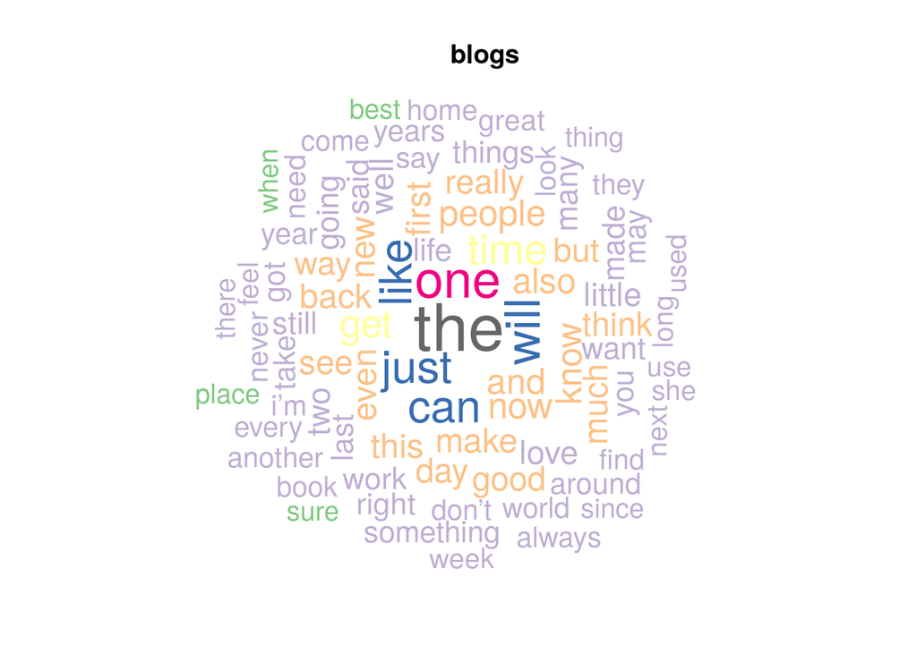

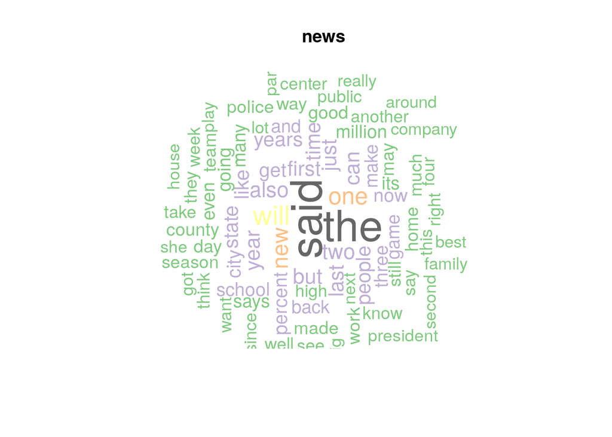

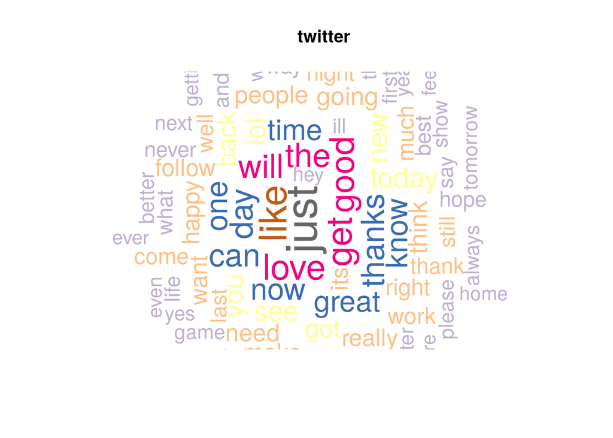

```r
for(i in 1:length(corpus)) {
  nm <- names(corpus)[i]
  wordcloud(corpus[i], max.words = 80, colors=brewer.pal(8, "Accent"),
            random.order = FALSE, rot.per = 0.45, scale = c(3, 1))
  title(nm)
}
```

Also, a histogram, segmented by word source, shows the overall distribution of unigrams.

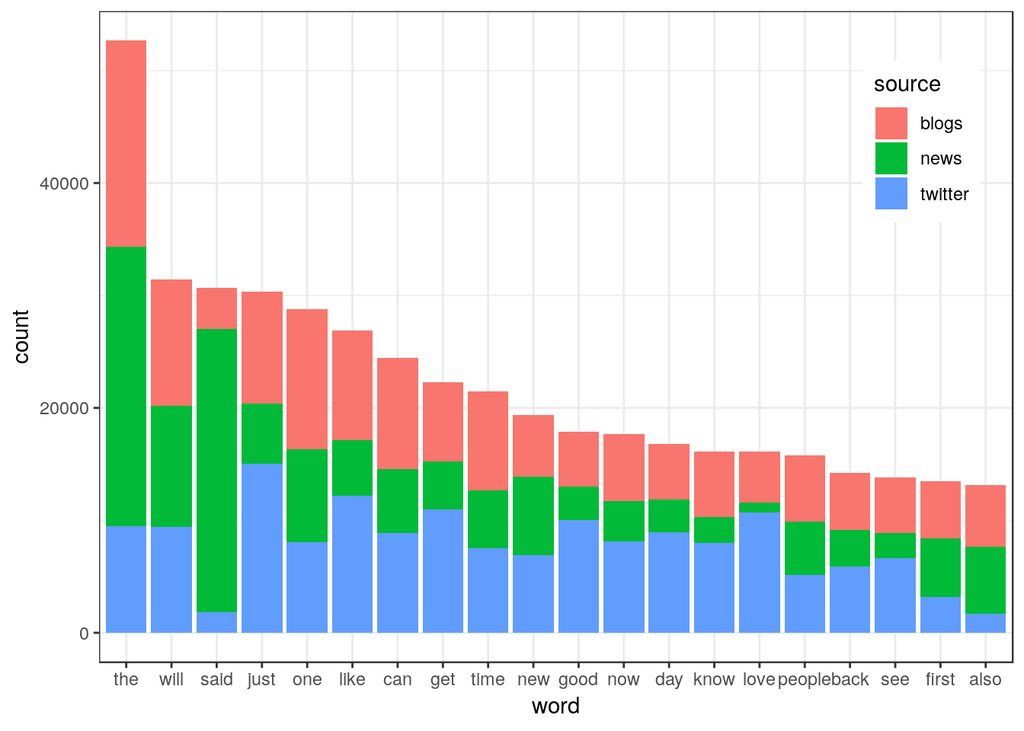

```r
tdm <- as.matrix(TermDocumentMatrix(corpus))
tdm <- as_tibble(tdm, rownames = "word")
tdm <- tdm %>%
  mutate(all = blogs + news + twitter) %>%
  arrange(desc(all))
tdm <- tdm %>% mutate(runningCount = cumsum(all))
tdm_wordLevels <- unique(tdm$word)
tdm_top <- tdm[1:20, c("word", "blogs", "news", "twitter")] %>%
  gather(key = "source", value = "count", 2:4)
tdm_top$word <- as_factor(tdm_top$word)
p <- ggplot(data = tdm_top,
            aes(x = word, y = count, fill = source),
            color = brewer.pal(3, "Accent")) +
  geom_bar(stat = "identity") +
  theme_bw() + theme(legend.position = c(0.9,0.8))
print(p)
```

#### Bigrams

```r
bigramTokenizer <- function(x) {
  unlist(lapply(ngrams(words(x), 2), paste, collapse = " "), use.names = FALSE)
}
tdm_bigrams <- as.matrix(
  TermDocumentMatrix(corpus, control = list(tokenize = bigramTokenizer)))
tdm_bigrams <- as_tibble(tdm_bigrams, rownames = "bigram")
tdm_bigrams <- tdm_bigrams %>%
  mutate(all = blogs + news + twitter) %>%
  arrange(desc(all))
tdm_bigrams[1:20,]
```

| bigram | blogs | news | twitter | all |
| --- | --- | --- | --- | --- |
| i think | 2406 | 1292 | 2516 | 6214 |
| i love | 1436 | 173 | 3229 | 4838 |
| i know | 1813 | 558 | 2228 | 4599 |
| i just | 1267 | 350 | 2269 | 3886 |
| i can | 1654 | 385 | 1638 | 3677 |
| i will | 1502 | 187 | 1364 | 3053 |
| i want | 1037 | 397 | 1526 | 2960 |
| right now | 498 | 365 | 1607 | 2470 |
| i like | 779 | 214 | 1163 | 2156 |
| i need | 578 | 69 | 1356 | 2003 |

[output cut: 10 more lines]

#### Trigrams

```r
trigramTokenizer <- function(x) {
  unlist(lapply(ngrams(words(x), 3), paste, collapse = " "), use.names = FALSE)
}
tdm_trigrams <- as.matrix(
  TermDocumentMatrix(corpus, control = list(tokenize = trigramTokenizer)))
tdm_trigrams <- as_tibble(tdm_trigrams, rownames = "trigram")
tdm_trigrams <- tdm_trigrams %>%
  mutate(all = blogs + news + twitter) %>%
  arrange(desc(all))
tdm_trigrams[1:20,]
```

| trigram | blogs | news | twitter | all |
| --- | --- | --- | --- | --- |
| i think i | 335 | 56 | 373 | 764 |
| i know i | 338 | 70 | 302 | 710 |
| i feel like | 189 | 66 | 375 | 630 |
| i wish i | 131 | 28 | 361 | 520 |
| happy mothers day | 6 | 0 | 299 | 305 |
| i thought i | 165 | 36 | 102 | 303 |
| new york city | 97 | 138 | 41 | 276 |
| let us know | 31 | 8 | 223 | 262 |
| i just want | 76 | 34 | 139 | 249 |
| every time i | 101 | 25 | 112 | 238 |

[output cut: 10 more lines]

### nGram Coverage

A fraction of the words in a frequency sorted dictionary can be used to cover most of the the total word instances in the set.

```r
tdm <- tdm %>% mutate(runningCount = cumsum(all))
totalUnigrams <- sum(tdm$all)
cover50 <- which(abs(tdm$runningCount - (0.5 * totalUnigrams)) ==
        min(abs(tdm$runningCount - (0.5 * totalUnigrams))))
cover90 <- which(abs(tdm$runningCount - (0.9 * totalUnigrams)) ==
        min(abs(tdm$runningCount - (0.9 * totalUnigrams))))
```

- total uni-grams present = 5,622,915
- number of uni-grams to cover 50% = 972
- number of uni-grams to cover 90% = 17,116

## Other Considerations

### Foreign Words

Some unigrams found are obviously come from a foreign languages. These could be programitally identified by excluding those containing non-ASCII characters. They, however, do not make up a large enough percentage to warrant adding them to a stopwords list.

### Methods to Increase Coverage

As shown with the coverage estimates, a reduced dictionary could be used to practically produce similiar results.